# get_pocket_stats

If you came here from the blog part of my website, you can go back to it by clicking [here](http://rahulporuri.github.io/blog.html) or if you came here from my blogpost, you can go back to it by clicking [here](http://rahulporuri.blogspot.in/).

I wanted to continue in the same direction as a couple of my other per projects and look at stats of an activity that I did regularly, which in this case is how I use the Pocket offline reading app. You can export your personal pocket data by going here. Again, I use the BeautifulSoup module to parse the .html file and I use the gmtime function in the time module to convert the 10-digit time stamp from the html file to something more meaningful, that we can understand. You can look at an example later in the code.

```python
import numpy
import matplotlib.pyplot as plt
%matplotlib inline
import BeautifulSoup
import time
```

again, if you take a closer look at the html file, you will notice that the time stamps are an attribute in the 'a' elements.

```python
soup = BeautifulSoup.BeautifulSoup(open('ril_export.html'))
allAttrs = [tag.attrs for tag in soup.findAll('a')]
```

```python
dates = []
for string in allAttrs:
        try :
                dates.append(str(string[1][1]).strip('u'))
        except IndexError :
                print string

dateList = numpy.asarray(dates, dtype=int)
print len(dateList)
```

```
1360
```

```python
yearList = []
monthList = []
dayList = []
hourList = []

for date in dateList:
        temp = time.gmtime(date)
        yearList.append(temp.tm_year)
        monthList.append(temp.tm_mon)
        dayList.append(temp.tm_mday)
        hourList.append(temp.tm_hour)

yearList = numpy.asarray(yearList)
monthrList = numpy.asarray(monthList)
dayList = numpy.asarray(dayList)
hourList = numpy.asarray(hourList)
```

```python
print list(set(yearList))
print list(set(monthList))
print list(set(dayList))
print list(set(hourList))
```

```
[2014, 2015]
[1, 2, 3, 4, 5, 6, 7, 8, 9, 10, 11, 12]
[1, 2, 3, 4, 5, 6, 7, 8, 9, 10, 11, 12, 13, 14, 15, 16, 17, 18, 19, 20, 21, 22, 23, 24, 25, 26, 27, 28, 29, 30, 31]
[0, 1, 2, 3, 4, 5, 6, 7, 8, 9, 10, 11, 12, 13, 14, 15, 16, 17, 18, 19, 20, 21, 22, 23]
```

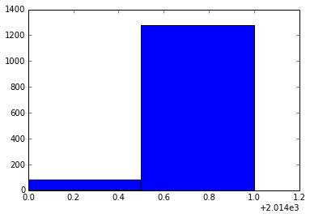

```python
plt.hist(yearList,bins=2)
```

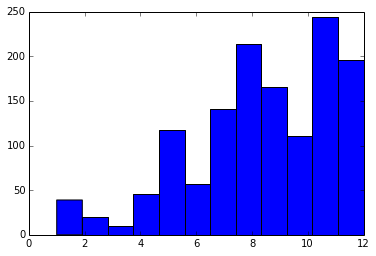

```python
plt.hist(monthList,bins=12)
```

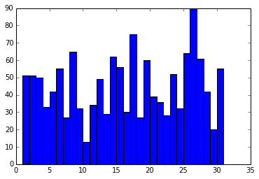

```python
plt.hist(dayList,bins=30)
```

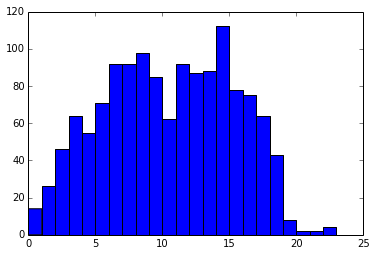

```python
plt.hist(hourList,bins=23)
```

If you came here from the blog part of my website, you can go back to it by clicking [here](http://rahulporuri.github.io/blog.html) or if you came here from my blogpost, you can go back to it by clicking [here](http://rahulporuri.blogspot.in/).